# Phage reazurin

tara

4/2/2020

Alice notes on experimental setup:

Stationary: - Grow overnight bacteria from a streaked plate - Add 200uL of overnight bacteria into 2mL BHI media - Shake at 37C for 2hrs - Then add 650uL of this bacteria + 650uL of 0.4% agar BHI - Plate 100uL into each well More bacteria: - Grow overnight bacteria from a streaked plate - Add 650uL overnight bacteria into 650uL of 0.4% agar BHI - Plate 100uL into each well Regular: - Grow overnight bacteria - Add 13uL of overnight bacteria into 1,287uL of heated BHI + 0.2% agar - Plate 100uL into each well Notes: - Phage stock locations found on Mission Control file under Phage tab - Plate dilutions before plating bacteria - For negative controls with bacteria: add 100uL of appropriate bacteria mixed with BHI + 0.2% agar then add 100uL SM buffer - BHI negative: add 100uL of BHI + 0.2% agar then add 100uL SM buffer - Final agar concentration per well is 0.1% - Final volume per well is 200uL - When using agar from room temp, microwave until boil then aliquot into 1.5/2mL tubes that can be put on the heatblock

```r
require(ggplot2)
require(xlsx)
require(reshape2)
# read in the data files
rz_data <-read.xlsx("Tara Rz 030220 Rz.xlsx",1)
rs_data <- read.xlsx("Tara Rz 030220 Rs.xlsx",1)
growth_data <- read.xlsx("Tara Rz 030220 OD700.xlsx",1)

#read in a map of the 96-well plate setup so we know which wells correspond to which condition
plate_setup<-read.xlsx("plate_setup.xlsx",1)
#reformat plate setup to obtain well location for each sample
plate_setup <- reshape2::melt(plate_setup, id.vars="NA.")
colnames(plate_setup) <- c("Row", "Column", "Label")
plate_setup$Column<-gsub(pattern="X", replacement="", plate_setup$Column)
plate_setup$index <- paste(plate_setup$Row, plate_setup$Column, sep="")
plate_setup <- na.omit(plate_setup)

# reformat the flouresnce and OD data files into ggplot2 friendly format
column_names<-t(rz_data[9,])
colnames(rz_data) <- as.character(column_names)
rz_data_fmt <- rz_data[-c(1:9),]
rz_data_fmt <- reshape2::melt(rz_data_fmt, id.var=c("Reading", "avg. time [s]"))
colnames(rz_data_fmt) <- c("Reading", "time_s","well_location", "AU")
rz_data_fmt$well_location <- gsub(pattern=".*\\(", replacement="", rz_data_fmt$well_location)
rz_data_fmt$well_location <- gsub(pattern=")", replacement="", rz_data_fmt$well_location)
rz_data_fmt$well_location <- gsub(pattern="0", replacement="", rz_data_fmt$well_location)
rz_data_fmt$Type <- c("Resazurin (oxidized)")

# repeat for other 2 data files
column_names<-t(rs_data[9,])
colnames(rs_data) <- as.character(column_names)
rs_data_fmt <- rs_data[-c(1:9),]
rs_data_fmt <- reshape2::melt(rs_data_fmt, id.var=c("Reading", "avg. time [s]"))
colnames(rs_data_fmt) <- c("Reading", "time_s","well_location", "AU")
rs_data_fmt$well_location <- gsub(pattern=".*\\(", replacement="", rs_data_fmt$well_location)
rs_data_fmt$well_location <- gsub(pattern=")", replacement="", rs_data_fmt$well_location)
rs_data_fmt$well_location <- gsub(pattern="0", replacement="", rs_data_fmt$well_location)
rs_data_fmt$Type <- c("Resorufin (reduced)")

column_names<-t(growth_data[9,])
colnames(growth_data) <- as.character(column_names)
growth_data_fmt <- growth_data[-c(1:9),]
growth_data_fmt <- reshape2::melt(growth_data_fmt, id.var=c("Reading", "avg. time [s]"))
colnames(growth_data_fmt) <- c("Reading", "time_s","well_location", "AU")
growth_data_fmt$well_location <- gsub(pattern=".*\\(", replacement="", growth_data_fmt$well_location)
growth_data_fmt$well_location <- gsub(pattern=")", replacement="", growth_data_fmt$well_location)
growth_data_fmt$well_location <- gsub(pattern="0", replacement="", growth_data_fmt$well_location)
growth_data_fmt$Type <- c("Growth (OD700)")

#combine all 3 data files into 1 dataframe
all_data <- rbind(rz_data_fmt, rs_data_fmt, growth_data_fmt)
# add condition labels by merging with plate_setup
all_data <-merge(x=all_data, y=plate_setup, by.x="well_location", by.y="index", all.y=TRUE)

all_data<-na.omit(all_data)
```

```r
all_data$time_s <- as.numeric(as.character(all_data$time_s))
all_data$time_h <- all_data$time_s/3600

### add new column to dataframe to allow for facetting
all_data$sample_category <- ifelse(all_data$Label=="BHI Neg" | all_data$Label == "SM Only" ,"Solvent Background", "Sample" )

all_data$sample_category <- ifelse(grepl("Stat", all_data$Label),"Stat host", all_data$sample_category )
all_data$sample_category <- ifelse(grepl("Half", all_data$Label),"Overnight host", all_data$sample_category )
all_data$sample_category <- ifelse(grepl("Reg", all_data$Label),"100-fold diluted host", all_data$sample_category)

all_data$phage_dilution <- all_data$Label
all_data$phage_dilution <-ifelse(grepl("10", all_data$Label), gsub(pattern=".*10-", replacement="", all_data$Label), all_data$phage_dilution)
all_data$phage_dilution <-gsub(pattern="1", replacement="10-fold phage dilution", all_data$phage_dilution )
all_data$phage_dilution <-gsub(pattern="2", replacement="100-fold phage dilution", all_data$phage_dilution )
all_data$phage_dilution <-gsub(pattern="3", replacement="1000-fold phage dilution", all_data$phage_dilution )
all_data$phage_dilution <-ifelse(grepl("Neg", all_data$Label), "Neg", all_data$phage_dilution)
all_data$phage_dilution <-ifelse(grepl("Stock", all_data$Label), "Phage Stock", all_data$phage_dilution)



# det number of time-points
max(as.numeric(as.character(all_data$Reading)))
```

```
## [1] 720
```

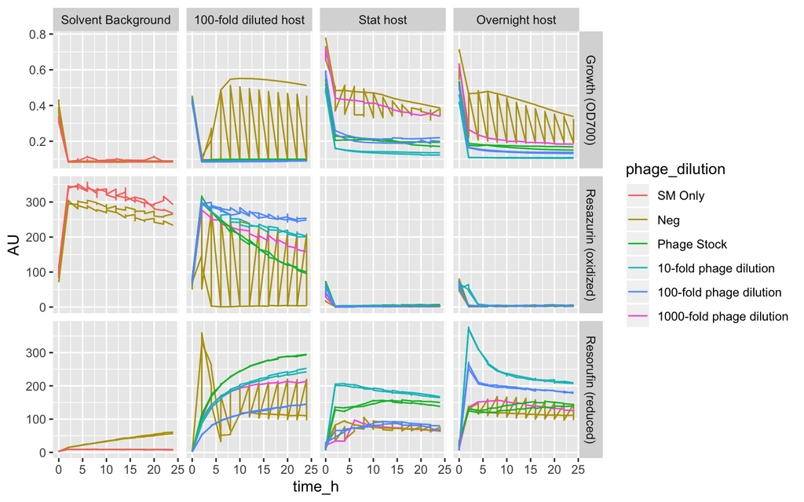

```r
# 720 is a lot, will be slow to plot!
# select certain time-points to plot
# e.g. plot the data from every 2h
all_data$time_h <- round(all_data$time_h,1)
desired_hours <- seq(from=0, to=24, by=2)

all_data_subset <- all_data[all_data$time_h %in% desired_hours,]
all_data_subset$AU <- as.numeric(as.character(all_data_subset$AU ))

all_data_subset$phage_dilution <- factor(all_data_subset$phage_dilution, levels = c("SM Only", "Neg", "Phage Stock", "10-fold phage dilution", "100-fold phage dilution", "1000-fold phage dilution"))

all_data_subset$sample_category <- factor(all_data_subset$sample_category, levels = c("Solvent Background", "100-fold diluted host", "Stat host", "Overnight host"))

timeplot1<-ggplot()+geom_line(data=subset(all_data_subset), aes(x=time_h, y=AU, color=phage_dilution, group=well_location))+
  facet_grid(Type~sample_category, scales="free")

timeplot1
```

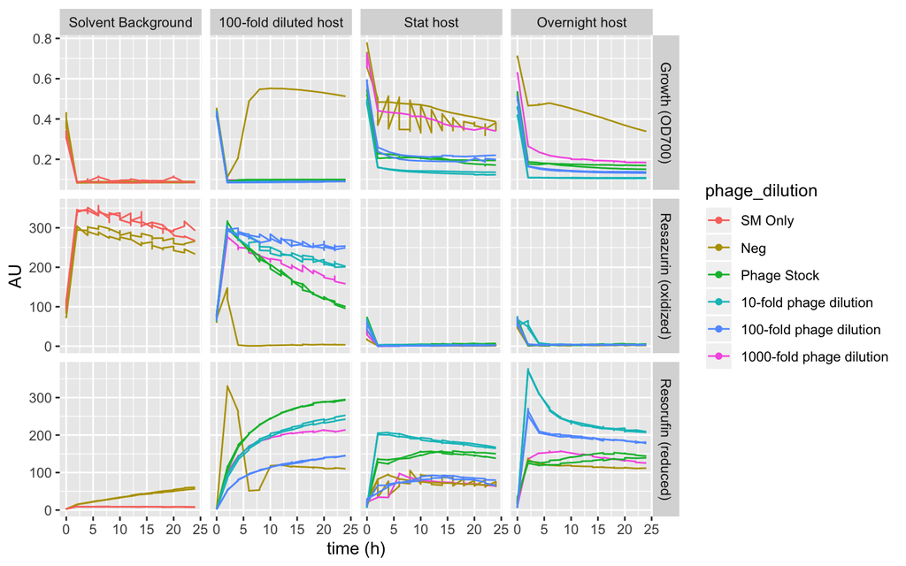

```r
# one of the negative controls looks weird, remove and replot
timeplot2 <- ggplot()+geom_line(data=subset(all_data_subset, well_location!="F1" & well_location!="D1"), aes(x=time_h, y=AU, color=phage_dilution, group=well_location))+
  geom_point(data=subset(all_data_subset, well_location!="F1" & well_location!="D1"), aes(x=time_h, y=AU, color=phage_dilution, group=well_location,   shape=phage_dilution))+
  facet_grid(Type~sample_category, scales="free")+
  scale_shape_manual(values=21,22,23,24,25,21,22)+
  xlab("time (h)")

timeplot2
```

Notes: *hard to interpret data, the neg controls were noisy* probably need to change experimental set up, so no agar